# Introdução à Ciência de Dados

Análise Exploratória de Dados - Gráfica

Prof. Washington Santos da Silva

IFMG - Campus Formiga

4 de junho de 2025

## Diário de Bordo

**O que vimos até hoje?**

- Aula 1 ✅
  - Introdução e Contextualização ✅
  - O que é Ciência de Dados? ✅
  - Papéis Profissionais na Área de Dados ✅
  - Áreas de Aplicações ✅
  - Habilidades Interpessoais e Analíticas ✅
  - Apresentação da Disciplina ✅
- Aula 2 ✅
  - Metodologia CRISP-DM ✅
  - Tipos de Análise ✅
    - Descritiva ✅
    - Diagnóstica ✅
    - Preditiva ✅
    - Prescritiva ✅
  - Configurações: Git/GitHub ✅
- Aula 3 ✅
  - Introdução ao RStudio ✅
    - Criação do **seu** Projeto RStudio da Disciplina ✅
- Aula 4 ✅
  - Introdução ao Git e GitHub ✅
    - Criação do **seu** repositório do projeto RStudio da disciplina no GitHub ✅
- Aula 5 ✅
  - Breve Revisão do IDE RStudio ✅
  - Introdução ao Sistema de Publicação Quarto ✅
  - Sessão Prática Guiada com Relatório 1 ✅
    - Execução dos comandos git essenciais ✅
- Aula 6 ✅
  - Parte I ✅
    - O Relatório Junglivet e a Metodologia CRISP-DM ✅
    - Primeiro contato com a linguagem R por meio dos códigos do relatório ✅
  - Parte II ✅
    - Para alunos com projetos estruturados ✅
    - Atividade prática ✅
    - Para alunos com dificuldades técnicas ✅
    - Atendimento individualizado para estruturação de projetos ✅
- Aula 7 ✅
  - Introdução ao sistema Quarto (continuação) ✅
    - Gerar relatório no formato pdf ✅
    - Gerar relatório no formato docx ✅
  - Introdução à Linguagem R (continuação) ✅
    - Conceitos: Variáveis e observações ✅
    - Estrutura tabular organizada de dados ✅
    - Tipos e classes de dados principais em R ✅
    - Estruturas de dados: vetores e data frames ✅
- Aula 8 ✅
  - Início do estudo do pacote dplyr para manipulação de dados ✅
    - CRISP-DM: Fase 2 (Entendimento dos dados) e Fase 3 (Preparação dos dados) ✅  
      de um projeto de análise ou ciência de dados ✅
    - O que é o dplyr? ✅
    - A Filosofia *Tidy Data* (Dados Organizados) ✅
    - Dados Organizados (*Tidy Data*) ✅
    - Por que usar o dplyr? ✅
    - Fluxo de trabalho com dplyr ✅
    - Boas Práticas com dplyr ✅
    - Função dplyr::select() ✅
    - Função dplyr::filter() ✅
- Aula 9 ✅
  - Solução dos exercícios práticos sobre as funções select e filter ✅
  - Função dplyr::mutate() ✅
- Aula 10 ✅
  - Soluções dos exercícios práticos sobre a função mutate ✅
  - funções dplyr::group_by(), dplyr::summarize() e dplyr::arrange() ✅
- Aula 11 ✅
  - Metodologia CRISP-DM e Pacote dplyr ✅
  - Revisão sobre Dados Organizados (*Tidy Data*) ✅
  - Exemplos de Dados Desorganizados Comuns em Administração ✅
  - Pacote tidyr: Função pivot_longer ✅
- Aula 12 ✅
  - Metodologia CRISP-DM e o tidyverse ✅
  - Dados Organizados: Potencializando Análises ✅
- Aula 13 ✅
  - Avaliação 1 ✅
- Aula 14 ✅
  - Tipos Básicos de *joins* do pacote dplyr ✅
- Aula 15 ✅
  - Variáveis Aleatórias em Finanças ✅
  - Distribuições de Probabilidade ✅
  - Início: Distribuição Normal (ou Gaussiana) ✅
- Aula 16 ✅
  - Distribuição Normal (ou Gaussiana) - Parte 2 ✅
  - Características da Distribuição de uma VA ✅
    - Valor Esperado (Média) ✅
- Aula 17 ✅
  - Características da Distribuição de uma VA ✅
    - Variância e Desvio-Padrão ✅
    - Variância: Propriedades Básicas ✅
    - Aplicação: Valor-em-Risco (VaR) ✅
    - Assimetria e Curtose ✅
- Aula 18 ✅
  - Características da Distribuição de uma VA ✅
    - Covariância e Correlação ✅
    - Fundamentos de Simulação de Monte Carlo ✅
- Aula 19 ✅
  - Teoria da Probabilidade e Análise Estatística de Dados ✅
  - CRISP-DM e Análise Exploratória de Dados ✅
  - Análise Exploratória Numérica ✅
    - Medidas de Posição (ou de Tendência Central) ✅
    - Medidas de Variabilidade ✅
    - Medidas de Correlação ✅

## Avaliaçao 2

**Data**

- A Avaliação 2 será aplicada no dia **18/06/2025**, quarta-feira

## Nesta Aula

**Tópicos**

- Análise Exploratória Gráfica
  - Visualização de Dados e o Pacote ggplot2
  - Gráficos para Visualizar a Distribuição de Variáveis Numéricas
    - Histograma
    - Densidade Empírica (ou Kernel da Densidade)
    - Boxplot
    - Boxplot Comparativo

## Arquivo para esta Aula (20)

**Instruções**

- Abra o RStudio e o seu Projeto da Disciplina
- Crie a subpasta **12-relatorio** dentro da pasta **relatorios**.
- Acesse o site da disciplina e baixe o arquivo **12-relatorio.zip**
- Descompacte o arquivo, copie/recorte o arquivo `12-relatorio.qmd` e cole dentro da subpasta 12-relatorio.

## Na última Aula

**Análise Exploratória de Dados**

- Na última aula, vimos que uma análise exploratória de dados **numérica**, envolve calcular estatísticas para entender melhor algumas das características principais da distribuição dos dados, tais como:
  - Medidas de Tendência Central/Posição
  - Medidas de Variabilidade
  - Medidas de Correlação
- Entretanto, uma análise exploratória de dados é sobretudo **visual** ou gráfica — vamos nos concentrar nesta análise a partir desta aula.

**Diretrizes para Aulas Mais Produtivas**

🔊 **Mantenha conversas em volume baixo**

⌨️ **Código com método:**

95% dos erros são evitáveis com:

- Atenção na digitação
- Respeitar a sequência lógica de etapas
- Revisão antes de pedir ajuda

🤝 **Inteligência colaborativa:**

- Compartilhe conhecimento
- Resolva questões técnicas simples com colegas próximos
- Reserve ao professor as dúvidas conceituais complexas

💪 **Capacidade de Resolver Problemas**

Cada erro resolvido é uma evolução da sua habilidade analítica

# Visualização de Dados e o Pacote ggplot2

## O Quarteto de Anscombe

**Descrição**

**Francis Anscombe (1973)** criou quatro conjuntos de dados que demonstram a importância da visualização estatística de dados.

**Pergunta central:** Estatísticas descritivas são suficientes para compreender conjuntos de dados?

**Spoiler:** Definitivamente não!

## O Quarteto de Anscombe

```r
# Carregando o conjunto de dados Anscombe (built-in no R)
data(anscombe)
head(anscombe)
```

```
  x1 x2 x3 x4   y1   y2    y3   y4
1 10 10 10  8 8.04 9.14  7.46 6.58
2  8  8  8  8 6.95 8.14  6.77 5.76
3 13 13 13  8 7.58 8.74 12.74 7.71
4  9  9  9  8 8.81 8.77  7.11 8.84
5 11 11 11  8 8.33 9.26  7.81 8.47
6 14 14 14  8 9.96 8.10  8.84 7.04
```

**Quatro pares de variáveis:** (x1,y1), (x2,y2), (x3,y3), (x4,y4)

## Estatísticas Descritivas

```
# A tibble: 4 × 11
  grupo   x_média  x_dp x_mediana x_assimetria x_curtose y_média  y_dp y_mediana
  <chr>     <dbl> <dbl>     <dbl>        <dbl>     <dbl>   <dbl> <dbl>     <dbl>
1 Dados 1       9  3.32         9         0        -1.22    7.50  2.03      7.58
2 Dados 2       9  3.32         9         0        -1.22    7.50  2.03      8.14
3 Dados 3       9  3.32         9         0        -1.22    7.5   2.03      7.11
4 Dados 4       9  3.32         8         2.85      6.1     7.50  2.03      7.04
# ℹ 2 more variables: y_assimetria <dbl>, y_curtose <dbl>
```

## Visualização do Quarteto

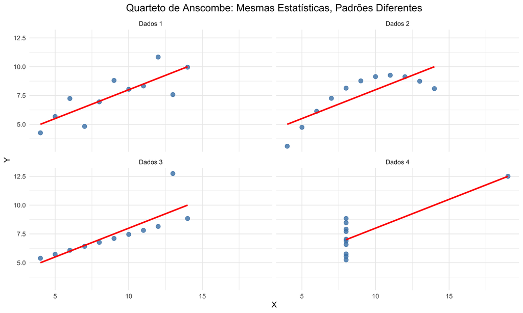

## Interpretação dos Padrões

**Interpretação dos Gráficos**

**Dados 1:**

- Relação linear clara
- Modelo linear adequado

**Dados 2:**

- Relação não-linear clara
- Modelo linear inadequado

**Dados 3:**

- Relação linear perfeita com 1 outlier
- Outlier influente

**Dados 4:**

- Sem correlação entre x e y
- Outlier cria correlação artificial

**Lição:** As mesmas estatísticas podem mascarar padrões completamente diferentes!

## Lições do Quarteto de Anscombe

**Lições**

1. **Análise exploratória visual** é obrigatória antes da análise/modelagem
2. **Estatísticas descritivas** podem mascarar padrões importantes
3. **Outliers e não-linearidades** só são detectados visualmente
4. **Comunicação efetiva** requer gráficos bem construídos
5. **Diagnósticos gráficos** são essenciais para validar modelos

**Princípio fundamental:** Sempre visualize antes de analisar/modelar!

## Visualização de dados

> *“O gráfico mais simples trouxe mais informações à mente do analista de dados do que qualquer outro dispositivo.” — John Tukey*

## Visualização de dados

**O que é Visualização de Dados?**

- **Visualização de dados** é a criação e o estudo da representação visual de dados
- É uma subárea de pesquisa em Estatística, Ciência de Dados e de outras áreas
- Muitas ferramentas para visualizar dados – a linguagem R é uma delas
- Muitas abordagens/sistemas dentro de R para criar visualizações de dados - o pacote **ggplot2** é um deles, e é esse pacote que vamos usar.

## Pacote ggplot2 $\in$ Tidyverse

[figure not shown]

- ggplot2 é o pacote de visualização de dados do tidyverse
- `gg` em “ggplot2” significa Gramática de Gráficos
- Inspirado no livro *Grammar of Graphics* de Leland Wilkinson

## Gramática dos Gráficos

- Um gráfico é construído por camadas (*layers*):
  - Dados
  - Mapeamento Estético
  - Geometria
  - Estatísticas
  - Coordenadas
  - Facetas
  - Temas


## Estrutura Básica do ggplot2

**Descrição**

Sintaxe básica do ggplot2:

```r
ggplot(data = data_frame,
       mapping = aes(x = var_x, y = var_y)) +
  geom_<tipo>()
```

A estrutura básica é composta por quatro componentes essenciais:

**1. Função ggplot()** → Cria um sistema de coordenadas vazio onde o gráfico será construído

**2. Dados** → `data = data_frame` especifica o conjunto de dados

**3. Mapeamento Estético** → `aes(...)` define como as variáveis são mapeadas aos elementos visuais

**4. Geometria** → `geom_<tipo>()` determina o tipo de gráfico (pontos, linhas, barras, etc.)

A função `ggplot()` estabelece a base fundamental criando um sistema de coordenadas vazio que recebe os dados e mapeamentos estéticos. As camadas gráficas subsequentes são adicionadas através do operador `+`.

## Mapeamento Estético - `aes()`

**O que faz?**

- **Mapeia/conecta variáveis a elementos visuais do gráfico**

Sintaxe:

```r
aes(x = variavel_1,
    y = variavel_2,
    color = variavel_3,
    size = variavel_4,
    shape = variavel_5)
```

Principais Mapeamentos:

- `x = variavel_1` → eixo horizontal
- `y = variavel_2` → eixo vertical
- `color = variavel_3` → cor
- `size = variavel_4` → tamanho
- `shape = variavel_5` → forma

## Geometrias - `geom_*()`

**O que faz?**

**Define o tipo de gráfico que será criado**

Sintaxe:

```r
ggplot(...) +
  geom_point()   # exemplo: gráfico de dispersão
```

Tipos Comuns:

- `geom_histogram()` → histograma
- `geom_boxplot()` → boxplot
- `geom_point()` → gráfico de dispersão
- `geom_line()` → gráfico de linha
- `geom_bar()` e `geom_col()` → gráfico de barra

## Dados dos Exemplos

**Descrição**

Os dados `economics`, contidos no pacote ggplot2, contém séries temporais mensais de indicadores econômicos dos EUA coletados pelo *Bureau of Labor Statistics* e *Federal Reserve Economic Data*, cobrindo o período de julho de 1967 a abril de 2015.

Variáveis Disponíveis:

- **date** → Data da observação mensal (tipo atômico `Date`)
- **unemploy** → Número total de desempregados em milhares de pessoas (*Total Unemployed*)
- **uempmed** → Duração mediana do desemprego em semanas (*Median Duration of Unemployment*)
- **pce** → Gastos de consumo pessoal em bilhões de dólares (*Personal Consumption Expenditures*)
- **pop** → População total dos EUA em milhares de habitantes
- **psavert** → Taxa de poupança pessoal como percentual da renda disponível (*Personal Savings Rate*)

## Um Gráfico Exploratório

```r
# a função ggplot() cria um sistema de coordenadas vazio
ggplot(data = economics,
       mapping = aes(x = date, y = unemploy/1000)) +
  # adiciona um gráfico de linha
  geom_line()
```

## Um Gráfico Exploratório

[figure not shown]

Gráfico de linha exploratório

## Um Gráfico para Publicação

```r
# salva o gráfico em um objeto
grafico_desemprego_eua <-
# a função ggplot() cria um sistema de coordenadas vazio
ggplot(data = economics,
       mapping = aes(x = date, y = unemploy/1000)) +
  # adiciona um gráfico de linha
  geom_line(color = "steelblue", size = 1.2) +
  # adiciona zero no eixo Y
  scale_y_continuous(limits = c(0, 17), breaks = seq(0, 16, 2)) +
  # adiciona título, subtítulo, rótulos dos eixos e fonte
  labs(title = "Evolução do Desemprego Mensal nos EUA",
       subtitle = "Período: 1967-2015",
       x = "Período",
       y = "Total de Desempregados (em milhões)",
       caption = "Fonte: Bureau of Labor Statistics") +
  # define o tema do gráfico
  theme_minimal()

# exibe o gráfico
grafico_desemprego_eua
```

## Um Gráfico de linha para publicação

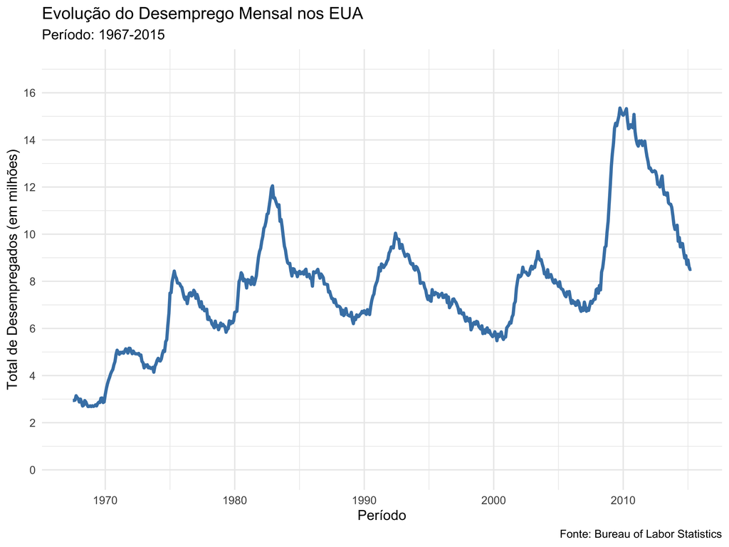

Evolução do Desemprego nos EUA (1967-2015)

## Boa Prática

**Por que incluir o zero no eixo Y?**

**Integridade na representação**: A ausência do zero distorce visualmente a magnitude real das variações.

**Contexto proporcional**: Para dados de desemprego, o zero fornece referência importante para avaliar mudanças econômicas.

**Quando o zero (talvez) pode ser omitido?**

- Em análises do nível de preços ou de índices financeiros consolidados. Exemplo: ações cujo preço varia entre $150-200 tornam imperceptíveis flutuações de 12% em gráficos com zero.
- Para indicadores econômicos como desemprego, receita, entre outros a inclusão do zero é importante.

# Gráficos para Visualizar a Distribuição de Variáveis Numéricas

## Gráficos da Distribuição de Variáveis Numéricas

**O que são?**

Características observáveis nos gráficos da **distribuição** de variáveis numéricas:

- **Simetria/Assimetria**: A distribuição é simétrica? Assimétrica à esquerda? ou assimétrica à direita?.
- **Modalidade**: A distribuição possui um ou dois ou mais picos (ou modas)?
- **Valores Extremos**: Há um ou mais valores muito distantes da maioria dos dados?
- **Variação**: Qual variável apresenta maior variação? Faz sentido somente ao comparar mais de uma variável.
- **Gaps**: Há intervalos de valores que não contém dados?
- **Erros**: Há valores fora do intervalo factível?

## Histograma

**O que é um histograma?**

- Um histograma é uma gráfico para visualizar a distribuição de uma variável aleatória numérica.
- Ele é construído dividindo o intervalo total dos dados em uma série de intervalos (*bins*), e o total de dados em cada intervalo é representada pela altura de cada barra.
- Assim, cada barra do histograma representa a **frequência** (número de ocorrências) dos dados dentro de um determinado intervalo de valores.

## Histograma: Interpretação da Forma

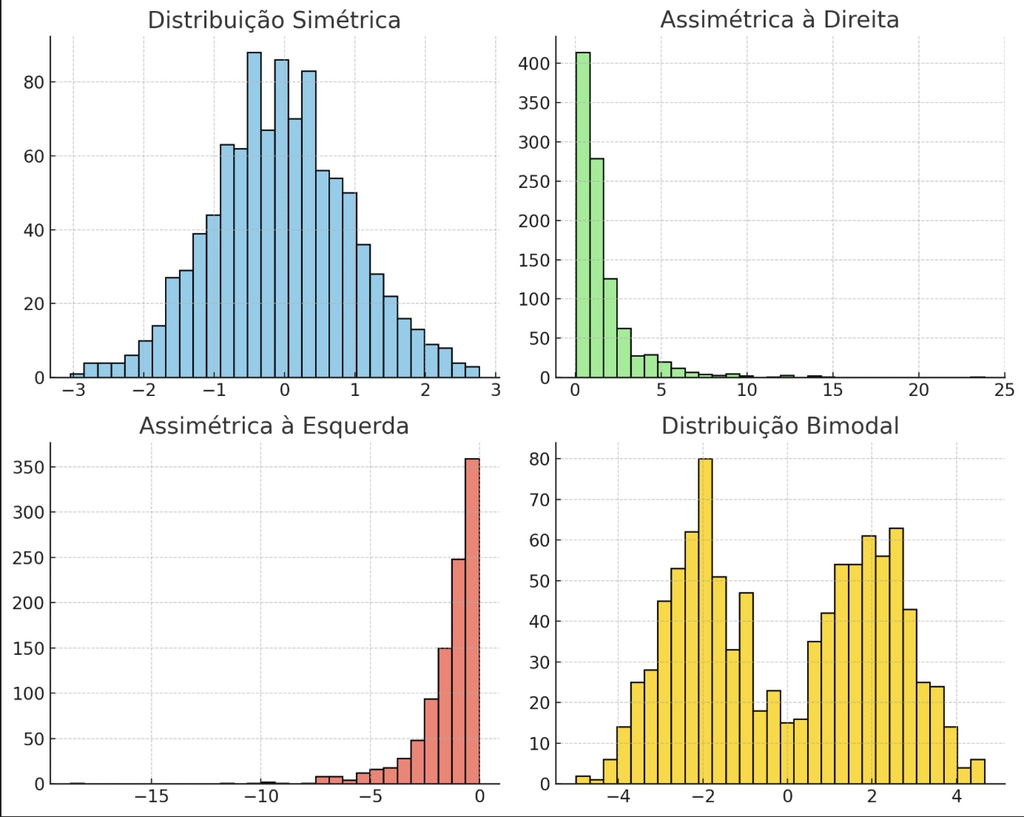

## Histograma exploratório

```r
# a função ggplot() cria um sistema de coordenadas vazio
ggplot(data = economics,
       mapping = aes(x = unemploy/1000)) +
  # adiciona um histograma
  geom_histogram()
```

## Histograma exploratório

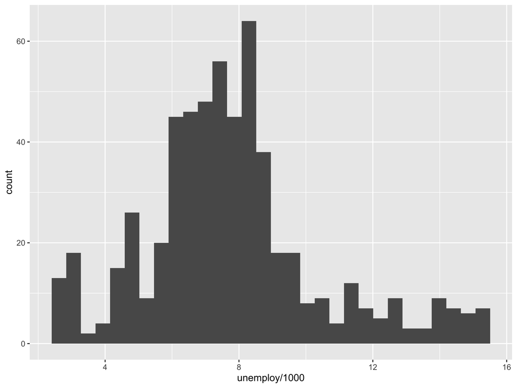

Histograma da Distribuição do Desemprego nos EUA (1967-2015)

## Efeito do Número de *Bins*

- 5 Intervalos
- 15 Intervalos
- 30 Intervalos

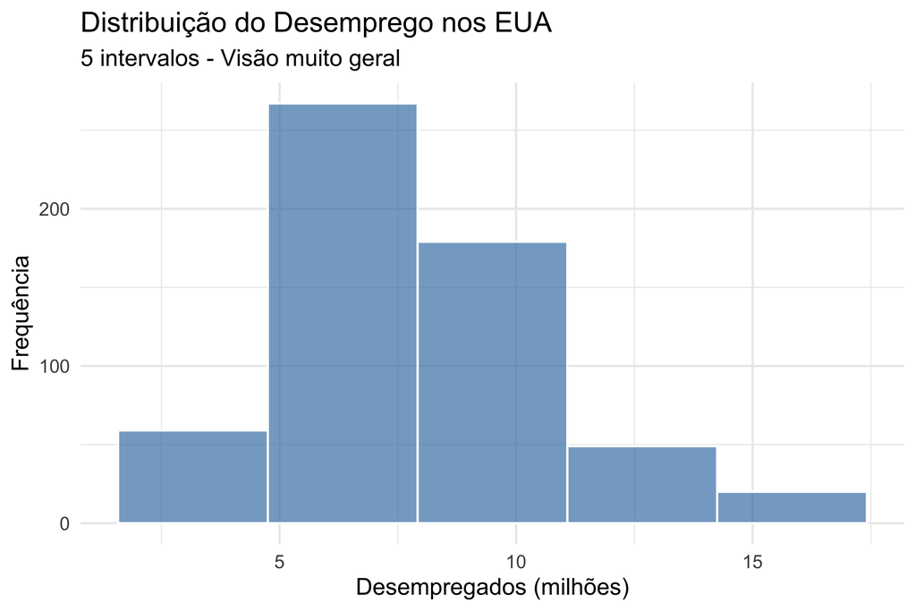

Histograma com 5 intervalos - Distribuicão com poucos detalhes

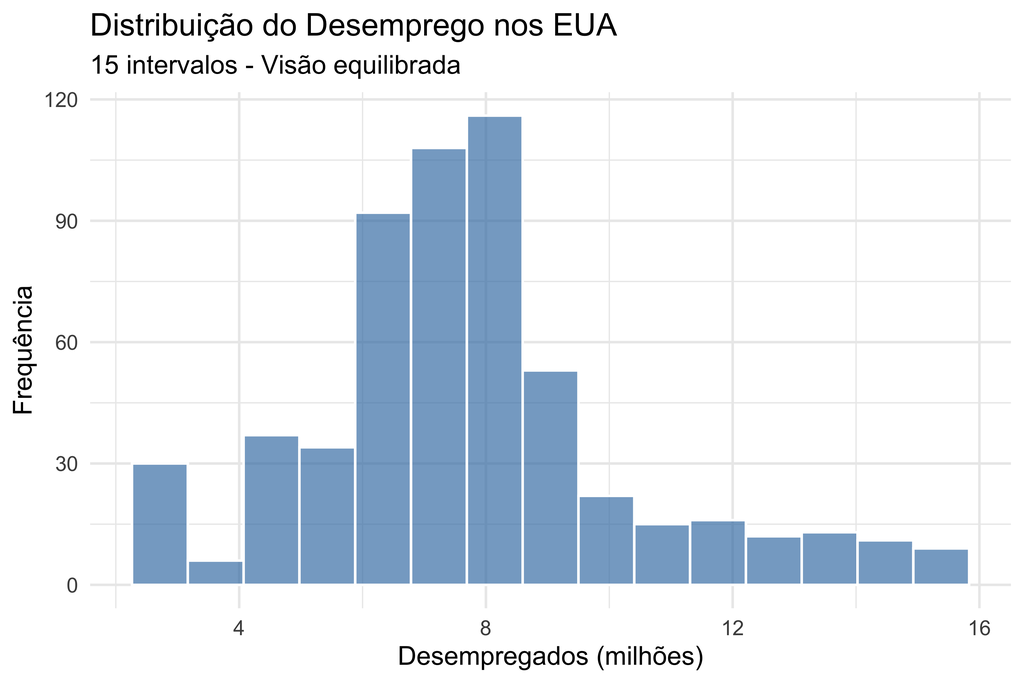

Histograma com 15 intervalos - Distribuição equilibrada

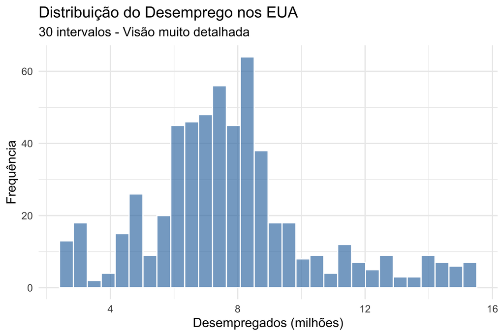

Histograma com 30 intervalos - Distribuição muito detalhada